# Shiny Application and Reproducible Pitch

17 de setembro de 2016

## Slide 1 - Overview

This presentation is part of Cousera Course Project: Shiny Application and Reproducible Pitch

The focus of the project is explore Data Visualization tools with R.

To visualize the data we created an application with shiny, you can access the application [here](https://gabrielclages.shinyapps.io/ShinyApp_Fiscal_Study/), or clicking the link below.

Shiny App: https://gabrielclages.shinyapps.io/ShinyApp_Fiscal_Study/

You can find more information about the application and all codes that I used on my [github](https://github.com/gabrielclages/ShinyApp_Fiscal_Study)

## Slide 2 - Preparing Data

Currently in Brazil one of the most widely discussed topic in political is the "fiscal pedaling" practiced by the federal government during the year of 2014.

To this study I collected data from [TCU](http://portal.tcu.gov.br/english/home.htm) (The Federal Court of Accounts of Brazil)

First step is to install packages, upload and prepare the dataset

## Slide 3 - Summarizing Data

```
##       Date         Month             Year      Seguro_Desemprego
##  abr.00 :  1   Min.   : 1.000   Min.   :1994   Min.   :-2.667e+09
##  abr.01 :  1   1st Qu.: 3.000   1st Qu.:1999   1st Qu.: 3.280e+07
##  abr.02 :  1   Median : 6.000   Median :2004   Median : 1.041e+08
##  abr.03 :  1   Mean   : 6.438   Mean   :2004   Mean   : 5.388e+07
##  abr.04 :  1   3rd Qu.: 9.000   3rd Qu.:2010   3rd Qu.: 1.918e+08
##  abr.05 :  1   Max.   :12.000   Max.   :2015   Max.   : 9.187e+08
##  (Other):254
##  Abono_Salarial       Bolsa_Familia          Balance           President
##  Min.   :-1.584e+09   Min.   :-2.018e+09   Length:260         Dilma :56
##  1st Qu.: 1.209e+07   1st Qu.: 0.000e+00   Class :character   FHC   :96
##  Median : 4.104e+07   Median : 0.000e+00   Mode  :character   Itamar:12
##  Mean   : 3.927e+07   Mean   : 4.695e+07                      Lula  :96
##  3rd Qu.: 1.143e+08   3rd Qu.: 1.539e+08
##  Max.   : 7.381e+08   Max.   : 4.182e+08
##
##  Fiscal_deficit   Presidential_election
##  Min.   :0.0000   Min.   :0.00000
##  1st Qu.:0.0000   1st Qu.:0.00000
##  Median :0.0000   Median :0.00000
##  Mean   :0.1038   Mean   :0.03846
##  3rd Qu.:0.0000   3rd Qu.:0.00000
##  Max.   :1.0000   Max.   :1.00000
##
```

## Slide 4 - Time series

This is the time series that we plot and explore in the application

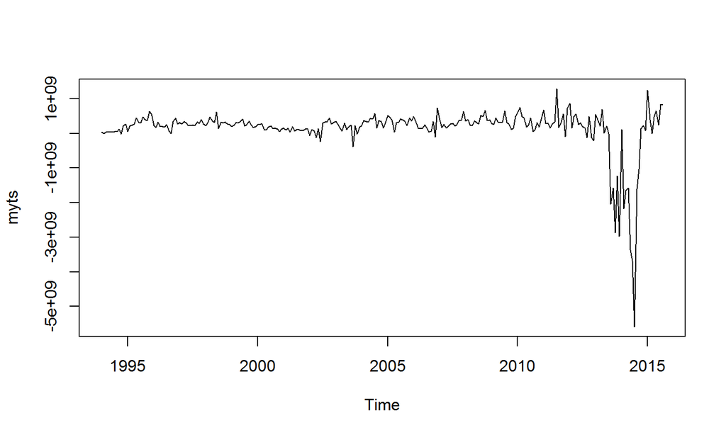

## Slide 5 - Application

To display the understanding of using shiny to build an application, an application has been developed and deployed at: https://gabrielclages.shinyapps.io/ShinyApp_Fiscal_Study/

The application allows the user to:

- Analyze the dataset in an interactive table
- Analyze the brazilian government balance time series in an interactive chart

Read the source at: https://github.com/gabrielclages/ShinyApp_Fiscal_Study